# The R Package of fast random SVD

基于Rcpp的快速随机奇异值分解包

李家郡

### 目录

> 为什么要用Rcpp

> 算法简介

> 制作R包的流程与注意事项

## 1 . 为什么用Rcpp

### 斐波那契数列运行效率对比

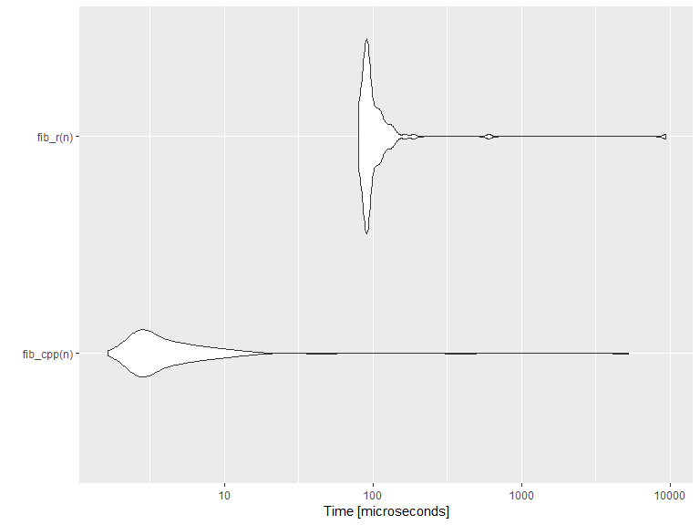

## 结合其他语言的原因

### 效率

- 观点1 程序员时间宝贵，有限时间写越短代码越好
- 观点2 学习R干嘛，cpp运行速度快，那都用cpp开发不就行了

### 结合其他语言的特性

- c++的特性
- Java的特性
- python的特性
- markdown的特性
- 未来c#?PPT

## 2.算法简介

### 随机分解算法原理解释

[interactive chart not shown]

- 将n×n的矩阵正交投影到n×s的低维空间，分解低维矩阵近似计算奇异值
- LU分解替代QR分解进一步加速
- Count Sketch替代Gaussian Sketch
- 提速关键在于降维与利用稀疏性

## 常用的矩阵运算库推荐

### Armadillo

RcppArmadillo

> 优点 矩阵分解快、语法接近Matlab、可链接多库

> 缺点 稀疏矩阵支持度不强，并行能力弱

### Eigen

RcppEigen

> 优点 稀疏支持好

> 缺点 分解速度太慢

### MKL

> 优点 快

> 缺点 不开源、与R耦合度低、配置麻烦

## Rpackage文件简介

### 文件目录

```
frSVD
│  DESCRIPTION              /描述文件，涉及到依赖关系
│  frSVD.Rproj
│  NAMESPACE                /添加useDynLib(mypackage),链接库载入、函数数据集全局可用
│
├─man
│      frSVD.rd             /帮助文档
│
├─R
│      RcppExports.R        /主文件，自动生成
│
└─src
        frpca.h
        frsvd.cpp
        frSVD.dll           /链接文件
        frsvd.o
        Makevars
        Makevars.win        /添加Rcpp中c++库的链接
        RcppExports.cpp
        RcppExports.o
```

### Description

```
Package: package name        /表示包的名称
Type: Package             /表示R-Project的类型，R包对应的为“Package”
Title: What the package does (short line)     /标题，简要描述R包功能
Version: 1.0                            /记录R包的版本信息
Author: Who wrote it                    /记录R包的作者
Maintainer: Who to complain to <yourfault@somewhere.net>   /记录R包的维护者
Description: More about what it does (maybe more than one line)  /详细描述R包的功能
License: GPL      /表示R包的使用许可(General Public License)
Encoding: UTF-8
Imports:   Rcpp, RcppArmadillo /使用的一些其他的包的名字,如这里用了RcppArmadillo
LinkingTo: Rcpp, RcppArmadillo /连接
SystemRequirements: C++11  /重点！使用Armadillo有可能需要C++11标准编译
```

### frSVD.rd包帮助描述部分

```
\name{mypackage-package}
\alias{mypackage-pakage}
\docType{mypackage}
\title{what the package does(short line)}
\description{More about what it does}
\details{
\tabular{ll}{Package、Type、Version、Date、License、LazyLoad}
}
\author{who wrote it}
\value{
  \item{函数返回变量}{ 返回变量类型说明}
}
\references{
Xu Fen, Yuyang Xie, Mingye Song Wenjian Yu, Jie Tang(2018). Fast Randomized PCA for Sparse Data. Proceedings of Machine Learning Research;see also https://arxiv.org/pdf/1810.06825.pdf
}
……
```

### frSVD.rd函数帮助描述部分

```
\name{mypackage-package}
\alias{mypackage-pakage}
\docType{mypackage}
\title{what the package does(short line)}
\description{More about what it does}
\usage{usage example}
\arguments{参数
  \item{参数名}{参数解释}
}
\examples{}
```

### frSVD.cpp外置部分

```
// [[Rcpp::depends(RcppArmadillo)]]
// [[Rcpp::plugins(cpp11)]]
#include "frpca.h"
#include <Rcpparmadillo.h>
#include <Rcpp.h>
#include <iostream>

using namespace Rcpp;

// [[Rcpp::depends(RcppArmadillo)]]
// [[Rcpp::export]]
RcppExport SEXP frSVD(arma::sp_mat& X,int k,int q=5) {
  frpca::frPCA fsvd(X,k,q);
  return Rcpp::List::create(
    Rcpp::Named("d")     = fsvd.singularValues(),
    Rcpp::Named("u")     = fsvd.matrixU(),
    Rcpp::Named("v")     = fsvd.matrixV(),
    Rcpp::Named("niter") = (q-1)/2,
    Rcpp::Named("rank")  = k);
}
```

## R包发布

### SCAN

麻烦，需要大量严格测试以及对包详尽的描述。  
（这些描述将存储在 vignettes文件夹中，可在主项目目录中创建该文件夹） 模拟测试并记录后，进入Build > Build Source Package 路径创建源码包。 在https://cran.r-project.org/submit.html提交源代码包

### GitHub

较容易(gitHub是一个面向开源及私有软件项目的托管平台)  
在 GitHub 上发布包最简单的方法是创建一个新的仓库，然后将主文件夹的内容上传至该仓库

```
devtools::install_github("llijiajun/frSVD")
```

## 本包使用说明

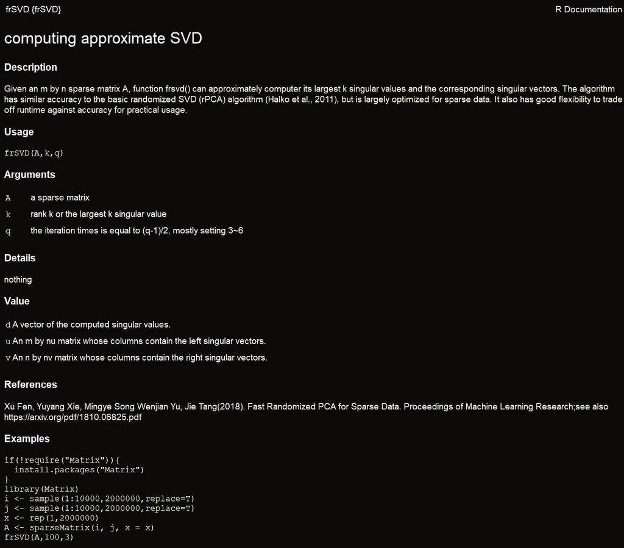

### 对比svds

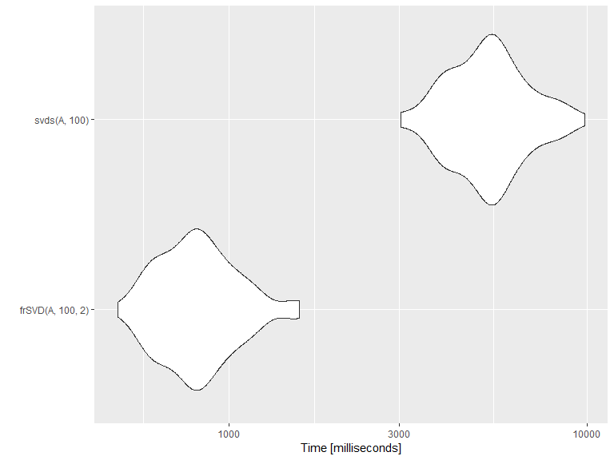

## 小结

### 建议

- 算法时间效率提高不仅限于算法本身，编程优化手段也很重要
- 研究算法最终目的还是将其投入实战，这是开发R包的根本目的

### 参考文献

- [1] Xu Fen, Yuyang Xie, Mingye Song Wenjian Yu, Jie Tang. Fast Randomized PCA for Sparse Data. Proceedings of Machine Learning Research 80:1-16,2018.
- [2] N. Halko, P. G. Martinsson, and J. A. Tropp. Finding structure with randomness: Probabilistic algorithms for constructing approximate matrix decompositions. SIAM Review, 53(2):217–288, 2011.
- [3] http://arma.sourceforge.net/
- [4] https://cosx.org/2013/12/rcpp-introduction/
- [5] 德克·埃德比特尔著，寇强 张晔译. Rcpp: R与C++的无缝整合